# Model frequency~techtonics

Bridget

11/23/2020

## Load Packages

```r
library(tidyverse)
library(tidymodels)
library(janitor)
library(glue)
library(choroplethr)
library(choroplethrMaps)
library(leaflet)
```

## Read in Data

```r
setwd("/cloud/project/proposal")
volcano <- read_csv("../data/volcano.csv")
eruptions <- read_csv("../data/eruptions.csv")
events <- read_csv("../data/events.csv")
```

## Tidy Data Needed

```r
volcano_tecs <- volcano%>%
  #filter out Vitim Volcanic Field volcano as tec settings are unknown
  filter(tectonic_settings != "Unknown")%>%
  #seperate the tec setting from the crust
  separate(tectonic_settings, c("techtonic_setting", "crust"),
                    sep = "([/])")
```

```r
eruption_tecs<- left_join(volcano_tecs, eruptions,
                          by=c("volcano_number", "volcano_name",
                               "latitude", "longitude"))

eruption_tecs_fqncy <- eruption_tecs%>%
  count(volcano_number, volcano_name, techtonic_setting, crust) %>%
  mutate(frequency = as.factor(n))%>%
  #str_trim("crust", side = "left")%>%
  #ideally remove whitespace for easier use but leave for later
  filter(crust != " Crustal thickness unknown")
```

## Initial Visualisations

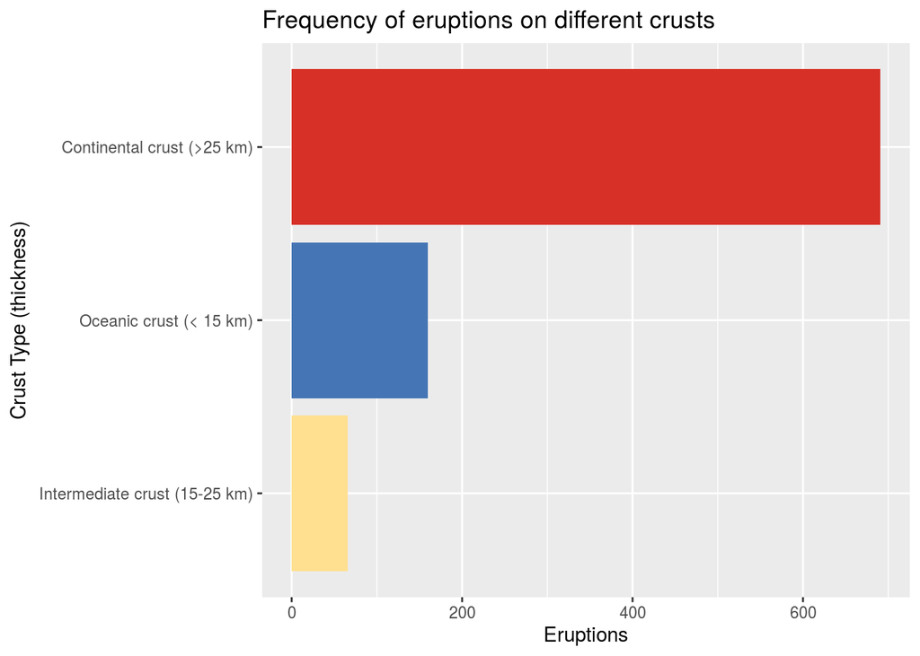

```r
eruption_tecs_fqncy%>%
  group_by(crust)%>%
  ggplot(aes(y = fct_rev(fct_infreq(crust)), fill = crust))+
  geom_bar()+
  labs(y = "Crust Type (thickness)",
       x = "Eruptions",
       title = "Frequency of eruptions on different crusts")+
  scale_fill_manual(values = c(
    " Continental crust (>25 km)" = "#d73027",
    " Oceanic crust (< 15 km)" = "#4575b4",
    " Intermediate crust (15-25 km)" = "#fee090"))+
  guides(fill = FALSE)
```

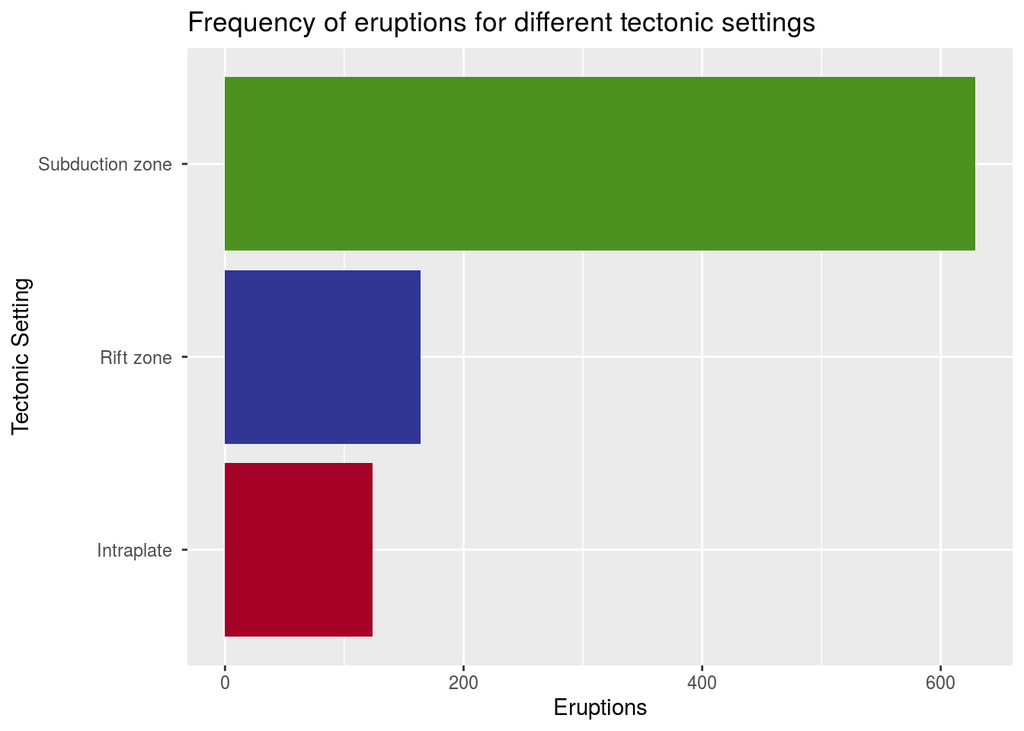

```r
eruption_tecs_fqncy%>%
  group_by(techtonic_setting)%>%
  ggplot(aes(y = techtonic_setting, fill = techtonic_setting))+
  geom_bar()+
    labs(y = "Tectonic Setting",
       x = "Eruptions",
       title = "Frequency of eruptions for different tectonic settings")+
  scale_fill_manual(values = c(
    "Intraplate " = "#a50026",
    "Rift zone " = "#313695",
    "Subduction zone " = "#4d9221"))+
  guides(fill = FALSE)
```

The first of the two visualizations above show that the majority of erruptions in the data set occur on continental crust which is over 25km thick. The second shows most erruptions in the dataset have occured from volcanos with the techtonic setting in the subduction zone

I aim to see if there is a model to support the hypothesis that it is a there is more likely to be a volcanic erruption if the volcano is lying on continental crust and has techtonic settings in the subduction zone than other crust types and techtonic settings.

## Linear Models

```r
tec_fit <- linear_reg()%>%
  set_engine("lm")%>%
  fit(n ~ techtonic_setting, data= eruption_tecs_fqncy)

  glance(tec_fit)$adj.r.squared
```

```
## [1] 0.01215089
```

The adjusted R squared for the linear model shows it only accounts for 1.2% of the data and therefore a linear model isn’t appropriate for the data, I will continue to explore general models to fit the data better.

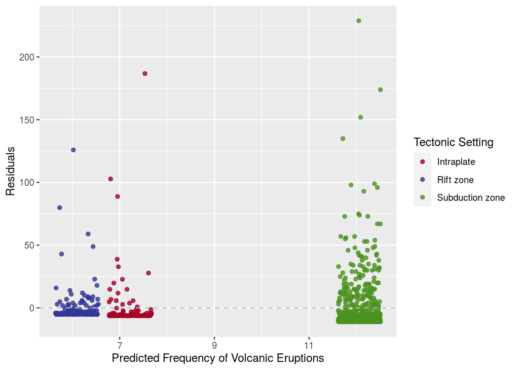

```r
tec_fit_aug <- augment(tec_fit$fit)

ggplot(tec_fit_aug, mapping=aes( x=.fitted, y =.resid,
                                 colour = techtonic_setting)) +
    geom_jitter(alpha=0.8) +
    geom_hline(yintercept=0, color="gray", lty="dashed" )+
    labs(x="Predicted Frequency of Volcanic Eruptions", y="Residuals",
         colour = "Tectonic Setting")+
    scale_colour_manual(values = c(
    "Intraplate " = "#a50026",
    "Rift zone " = "#313695",
    "Subduction zone " = "#4d9221"))
```

The residuals of predicted frequency seem to be in 3 distinct clusters. By adding an aesthetics arguement for colour of each tectonic setting it is clear that each of these clusters represents each setting. The plot further supports that a linear model is not appropriate for the data in question.

```r
crust_fit <-
linear_reg()%>%
  set_engine("lm")%>%
  fit(n ~ crust, data= eruption_tecs_fqncy)

  glance(crust_fit)$adj.r.squared
```

```
## [1] 0.002351574
```

The adjusted R squared for the linear model shows it only accounts for 0.2% of the data and therefore a linear model isn’t appropriate for the data, I will continue to explore general models to fit the data better.

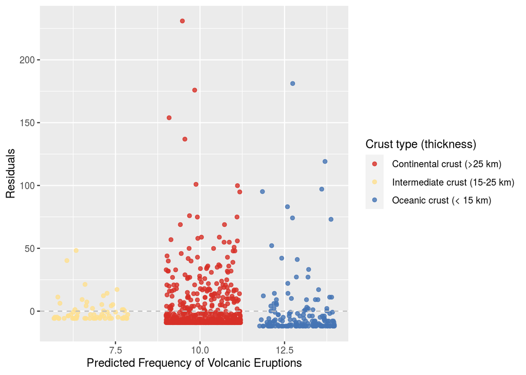

```r
crust_fit_aug <- augment(crust_fit$fit)

ggplot(crust_fit_aug, mapping=aes( x=.fitted, y =.resid, colour = crust)) +
    geom_jitter(alpha=0.8) +
    geom_hline(yintercept=0, color="gray", lty="dashed" )+
    labs(x="Predicted Frequency of Volcanic Eruptions", y="Residuals", colour = "Crust type (thickness)")+
  scale_colour_manual(values = c(
    " Continental crust (>25 km)" = "#d73027",
    " Oceanic crust (< 15 km)" = "#4575b4",
    " Intermediate crust (15-25 km)" = "#fee090"))
```

The residuals of predicted frequency seem to be in 3 distinct clusters. By adding an aesthetics arguement for colour of each crust type and thickness it is clear that each of these clusters represents each crust type. The plot further supports that a linear model is not appropriate for the data in question.

## Split Data

```r
set.seed(321)
tec_split <- initial_split(eruption_tecs_fqncy, prop = 0.80)
train_data_tec <- training(tec_split)
test_data_tec  <- testing(tec_split)
```

## General Model

```r
#tec_fit_log <-
  logistic_reg()%>%
  set_engine("glm")%>%
  fit(frequency ~ techtonic_setting, data= test_data_tec)%>%
  tidy()
```

```
## # A tibble: 3 x 5
##   term                                estimate std.error statistic p.value
##   <chr>                                  <dbl>     <dbl>     <dbl>   <dbl>
## 1 "(Intercept)"                       4.03e-15     0.500  8.07e-15   1.00
## 2 "techtonic_settingRift zone "       6.06e- 2     0.609  9.95e- 2   0.921
## 3 "techtonic_settingSubduction zone " 4.87e- 1     0.531  9.18e- 1   0.359
```

```r
#crust_fit_log <-
  logistic_reg()%>%
  set_engine("glm")%>%
  fit(frequency ~ crust, data= test_data_tec)%>%
  tidy()
```

```
## # A tibble: 3 x 5
##   term                                estimate std.error statistic p.value
##   <chr>                                  <dbl>     <dbl>     <dbl>   <dbl>
## 1 (Intercept)                           0.223      0.173     1.29   0.198
## 2 crust Intermediate crust (15-25 km)  -0.0896     0.546    -0.164  0.870
## 3 crust Oceanic crust (< 15 km)         0.916      0.442     2.07   0.0380
```

## Map visualizations

```r
tec_pal<- colorFactor(
  palette = c("#a50026", "#313695", "#4d9221"),
  domain = eruption_tecs$techtonic_setting
)
#red=intraplate
#blue=riftzone
#green=subductionzone


leaflet(eruption_tecs) %>%
  addTiles() %>%
  addCircleMarkers(
    ~longitude, ~latitude,
    radius = 3,
    color = ~tec_pal(techtonic_setting),
    stroke = FALSE,
    fillOpacity = 0.4
  )
```

[interactive chart not shown]

```r
crust_pal<- colorFactor(
  palette = c("#d73027", "#762a83", "#fee090", "#4575b4"),
  domain = eruption_tecs$crust
)
#red=continental
#yellow=intermediate
#blue=oceanic
#purple=unknown


leaflet(eruption_tecs) %>%
  addTiles() %>%
  addCircleMarkers(
    ~longitude, ~latitude,
    radius = 3,
    color = ~crust_pal(crust),
    stroke = FALSE,
    fillOpacity = 0.4
  )
```

[interactive chart not shown]

## Crust type and techtonics research

Earths Structure: The earth is formed of 4 layers, the crust, the mantle, the inner and outer core. In terms of volcano formation we are only really concerned with the crust and mantle. The crust is the top layer (the one we live on) which is a relatively thin layer of solid rock. This is split into sections known as tectonic plates which lie on top of the mantle- the second outermost layer formed of partially molten rock (magma) which moves very slowly. This causes the plates to move (only about a couple of cm per year) which, depending on the direction of movement can cause earthquakes and volcano formation.

Crust Type: In our data there are four categories for the crust type and thickness: Continental (land) Oceanic (sea) Intermediate Unknown Continental crust is much thicker than oceanic crust however oceanic crust is made of much denser rock than continental plates making them heavier despite their thin composition. After research it is still unclear what intermediate crust is however by observing the data they appear to categorize the crust type by thickness so it is potentially a collection of volcanos thicker than average oceanic crust and thinner than average continental crust.

Tectonic Settings: The tectonic setting of a volcano is the movements of the plates that has caused the formation of the given volcano. There are three different tectonic settings in the dataset: Subduction zone This when a continental and oceanic plate move towards each other, the heavier oceanic plate moves beneath the lighter continental plate, down into the mantle. This creates more magma and pressure near the surface which works its way through the continental plate to form a volcano. Rift zone This is when two plates are moving away from each other forming a gap in the crust which magma moves up through to form a volcano. Intraplate These form when there is a much hotter area of the mantle, causing the magma to rise to the surface where it is then pushed through the crust to form a volcano on the surface.

## Eruptions by year by crust

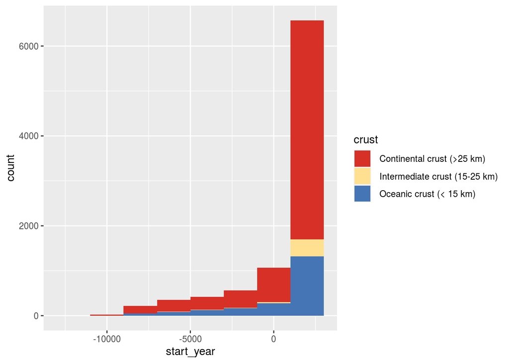

```r
eruption_tecs%>%
  group_by(crust)%>%
  filter(crust != " Crustal thickness unknown")%>%
  ggplot(aes(x= start_year,
             fill = crust))+
           geom_histogram(binwidth = 2000)+
    scale_fill_manual(values = c(
    " Continental crust (>25 km)" = "#d73027",
    " Oceanic crust (< 15 km)" = "#4575b4",
    " Intermediate crust (15-25 km)" = "#fee090"))
```

##Linear model take 2

```r
tec_fit_2 <- linear_reg()%>%
  set_engine("lm")%>%
  fit(n ~ techtonic_setting + crust, data= eruption_tecs_fqncy)

#adj r squared
glance(tec_fit_2)$adj.r.squared
```

```
## [1] 0.01804662
```

```r
#nope
```